# google_cert_r

Wes W.

2021-06-19

```r
install.packages('tidyverse')
install.packages('palmerpenguins')
```

```r
library(tidyverse)
library(palmerpenguins)
```

The cert course focuses on using ggplot2 for creating visualizations on data. ggplot2 is apart of the ‘tidyverse’ set of packages, so it’s included already tidyverse.

Basic construct for plots is **data** then (+) **geom** then (+) **aesthetics** then (+) **facets**. The *+* allows for chaining layers for the plot.

ggplot2 has a great [cheat sheet](https://github.com/rstudio/cheatsheets/blob/master/data-visualization-2.1.pdf).

### Basic empty plot

```r
ggplot(data=penguins)
```

[output not shown]

### Add a layer for rendering data with a geom

```r
ggplot(data=penguins) +
  geom_point(mapping=aes(x=bill_length_mm, y=bill_depth_mm))
```

[output not shown]

Here, the *aes()* is for defining the aesthetic for the plot. *geom_point* is the geom adding to the plot.

```r
ggplot(data=penguins) +
  geom_point(mapping=aes(x=flipper_length_mm, y=body_mass_g, color=species))
```

[output not shown]

Here, ggplot will automatically colorize the plot just by adding the color attribute to *aes()*

```r
ggplot(data=penguins) +
  geom_point(mapping=aes(x=flipper_length_mm, y=body_mass_g, shape=species))
```

[output not shown]

```r
ggplot(data=penguins) +
  geom_point(mapping=aes(x=flipper_length_mm, y=body_mass_g, shape=species, color=species, size=species))
```

[output not shown]

```r
ggplot(data=penguins) +
  geom_point(mapping=aes(x=flipper_length_mm, y=body_mass_g, alpha=species))
```

[output not shown]

Colors can also be defined directly

```r
ggplot(data=penguins) +
  geom_point(mapping=aes(x=flipper_length_mm, y=body_mass_g, alpha=species), color="orange")
```

[output not shown]

Geoms can be combined because they are simply layered with each other onto the plot

```r
ggplot(data=penguins) +
  geom_smooth(mapping=aes(x=flipper_length_mm, y=body_mass_g)) +
  geom_point(mapping=aes(x=flipper_length_mm, y=body_mass_g))
```

[output not shown]

Bar chart is a common graph. This is how it’s coded in R.

```r
ggplot(data=diamonds) +
  geom_bar(mapping=aes(x=cut, fill=cut))
```

[output not shown]

Setting *fill* to a data point will enable geom_bar to select colors automatically for each data point.

```r
ggplot(data=diamonds) +
  geom_bar(mapping=aes(x=cut, fill=clarity))
```

[output not shown]

## Facets

Facets are subsets or sub-groupings of the entire dataset. By specifying the data point to be a facet, ggplot2 will automatically split/sub-divide the dataset. A facet is added just like any other layer, with the *+* character.

There are two types of facets: *facet_wrap()* and *facet_grid()*.

Using *facet_wrap()*

```r
ggplot(data=penguins) +
  geom_point(mapping=aes(x=flipper_length_mm, y=body_mass_g, color=species)) +
  facet_wrap(~species)
```

[output not shown]

```r
ggplot(data=diamonds) +
  geom_bar(mapping=aes(x=color,fill=cut)) +
  facet_wrap(~cut)
```

[output not shown]

Using *facet_grid()*

```r
ggplot(data=penguins) +
  geom_point(mapping=aes(x=flipper_length_mm,y=body_mass_g,color=species)) +
  facet_grid(species~sex)
```

[output not shown]

## Annotations

Adding annotations will create another layer with extra information such as title, callouts etc

Adding title and citation information can be added with *labs()*.

```r
ggplot(data=penguins) +
  geom_point(mapping=aes(x=flipper_length_mm, y=body_mass_g, color=species)) +
  labs(title="Palmer Penguins: Body Mass vs. Flipper Length",
       subtitle="Sample of 3 peaguin species",
       caption="Data collected by Dr. Kristen Gorman")
```

[output not shown]

*annotate()* can be used for adding labeling/information inside of the plot itself.

```r
ggplot(data=penguins) +
  geom_point(mapping=aes(x=flipper_length_mm, y=body_mass_g, color=species)) +
  labs(title="Palmer Penguins: Body Mass vs. Flipper Length",
       subtitle="Sample of 3 peaguin species",
       caption="Data collected by Dr. Kristen Gorman") +
  annotate("text", x=220, y=3500, label="The Gentoos are the largest",
           color="purple", fontface="bold", size=4.5, angle=25)
```

[output not shown]

## Finally

Of course, all of these plots, data, and layers can be assigned to variables for reuse

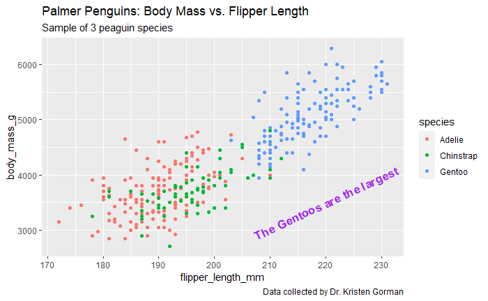

```r
penguin_plot <- ggplot(data=penguins)
penguin_geom <- geom_point(mapping=aes(x=flipper_length_mm, y=body_mass_g, color=species))
penguin_labs <- labs(title="Palmer Penguins: Body Mass vs. Flipper Length",
       subtitle="Sample of 3 peaguin species",
       caption="Data collected by Dr. Kristen Gorman")
penguin_annot <- annotate("text", x=220, y=3500,
                        label="The Gentoos are the largest", color="purple",
                        fontface="bold", size=4.5, angle=25)

penguin_plot + penguin_geom + penguin_labs + penguin_annot
```